# Project Demo for CPSC 103 Group 42

### Question 2: Explain how you used what you learned about systematic program design to solve the problem. What design choices did you have to make? Why did you make the choices that you made?

- **We used knowledge from systematic program design throughout the project**
- **The use of systematic program design can be seen in data definition, testing, examples, etc.**
- **We chose to use a bar chart in our project because the dataset is time oriented, and the bar chart is the best way to present the change in COVID-19 confirmed vs. tested ratio in one year.**

### Question 3: Describe how you solved the problem. Provide visuals if possible, and definitely provide the graph or chart(s) that your program created.

- **Due to the nature of this dataset, we have to design multiple filter functions to graph the correct ratio. (Because the data contains all the provinces throughout more than a year and contains empty data points.)**
- **The most crucial part is that since each row in the data only represents a day if we want to use each bar to represent a month, we have to design a function to sum the numbers in each month and calculate the percentage.**

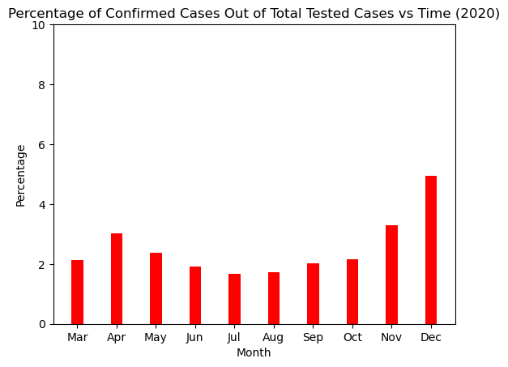

### Question 5: Provide examples of ways in which you could use your systematic programming design skills to solve problems in your chosen topic area in the future.

- **I believe using python to visualize large datasets is essential for all science-related projects beyond computer science. For example, I used python visualization (matplot) in my math project, which created a line chart and highlighted a specific coordinate.**